# Elite Schools

## Experiment Results

For each of the job applications, eleven data points were collected:

- `Block` - per the experimental design, the block associated with the subject
- `School` - (treatment) - undergraduate school represented on the resume
- `School Location` - geographic location of the undergraduate school (e.g., city, state)
- `Position` - employer name
- `Location` - geographic location of the employer’s job position (e.g., city, state)
- `Rating` - employer rating on glassdoor.com
- `Salary Low` - minimum salary of the advertised position, as advertised on glassdoor.com
- `Salary High` - maximum salary of the advertised position, as advertised on glassdoor.com
- `Date Applied` - the calendar date on which the we submitted a resume to the job position
- `Date Responded` - the calendar date on which we received a response, if any
- `Interested` - (outcome) - a yes/no indicator of whether the response we received was one that expressed interest in pursuing our candidacy

This raw data was codified for analysis. The *School* variable was used to categorize each job application as belonging to the treatment or control group, depending on whether the school was identified as elite by the experimental design. The *Interested* variable was used to assign a binary classification to treatment effect (e.g., whether or not a positive employer response was received for a job application). A lack of response, as well as a negative response from the employer, were both codified as a zero for treatment effect. As a descriptive characteristic of outcome, we also recorded the date on which employer responses were received to be able to look for differences in response timelines based on treatment assignment.

#### Outcome By Treatment and Block

The bar graph depicts the distribution of these results, color-coded by profession. Note that the outcome, ‘No Response’, is fairly consistent among the three professions and that the Teacher block did not have a single response that was “No”.

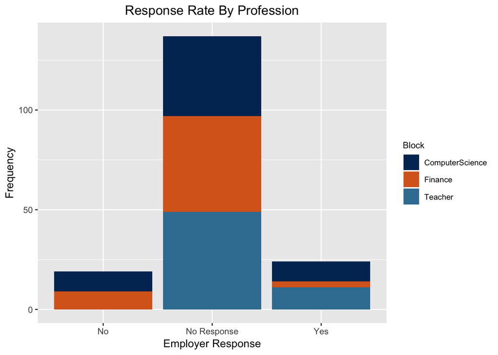

Two out of three blocks (Teacher, Finance) report a higher positive response rate for elite schools (measured in the hundredths). However, of note is the Computer Science block. While it was the only block to show a higher positive response rate for state schools, the difference recorded between treatment and control was far more significant than in the other blocks, measurable in the tenths digit.

For the positive responses received from employers, the table below depicts, by block, the number of days that passed between the experiment’s submission of a resume and the employers’ responses. The histogram is color-coded to highlight which responses are associated with each class of school. Note how most responses are aggregated within the first 10 days of applying.

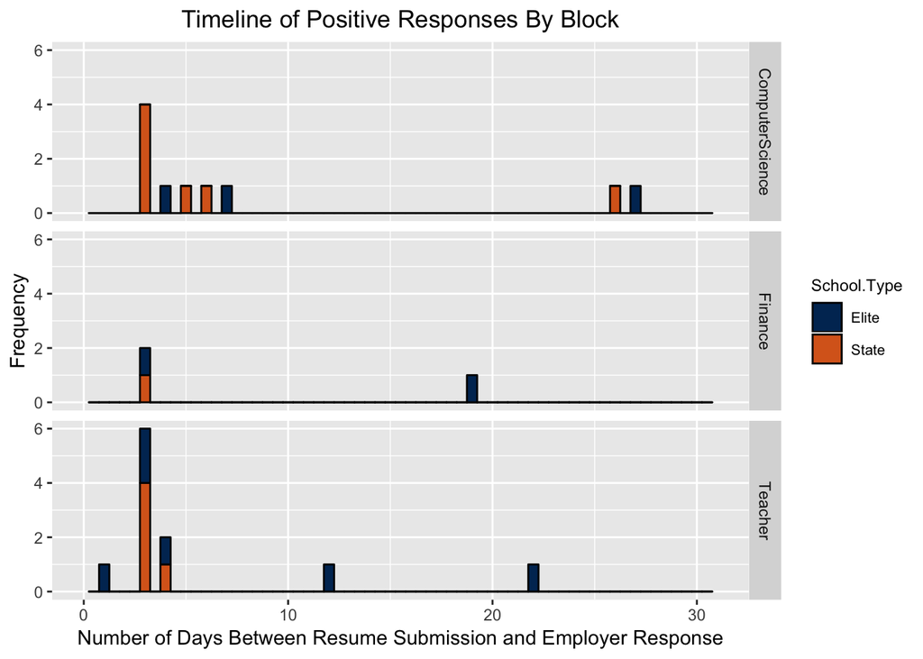

The graph highlights an interesting observation. With the exception of a single job application in the Computer Science block, only elite schools continue to generate responses past week one, ultimately driving the average mean positive response time of elite schools up.

### Covariate Examination

To test for covariate balance, treatment assignment is regressed on the covariates to test the null hypothesis that the covariates do not predict assignment into the treatment or control group. The p-values for each of the covariates are respectively, 0.45 for employer rating, 0.06 for distance, and 0.8 for salary. None fall below the p-value of 0.05, regarded as the standard for statistical significance.

A detailed look at each of the covariates’ definitions and distributions within each block follows.

###### Distribution of Employer Ratings

The employer rating on Glassdoor reflects the quality of the company as determined by its employees and may range from 0.0 to 5.0 stars. It was selected as a covariate of interest because we believed that there may be a correlation between employer rating and response rate, assuming that companies with higher ratings offer more desirable workplaces and/or benefits, thus increasing the competition for their positions and affecting our chance of advancing to an interview after a resume submission. For purposes of our analysis, we binned the ratings into intervals. The figure below depicts the distribution of these ratings, color-coded by profession.

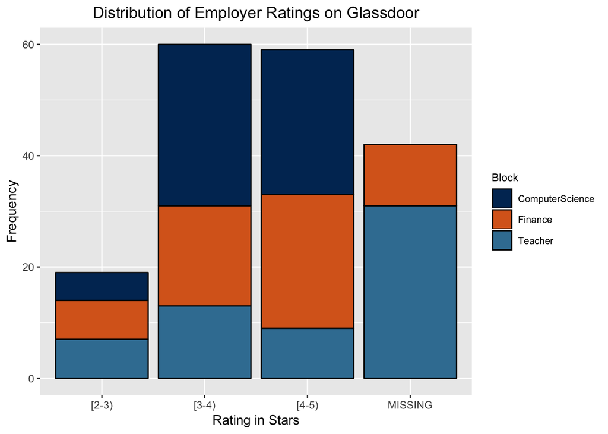

###### Distance

The distance measure reflects, in miles, the Euclidean distance between the school of the applicant (their presumed current place of residence) and the location of advertised job. It was selected as a covariate of interest because we believed that employers may show a preference to candidates more proximal to their location. We hypothesize this because we believe it could reduce employers’ potential exposure to relocation costs and that hiring managers may be more likely to be from nearby schools themselves (e.g., graduates of a state school are more likely to be from that state and settle post-college in that state). The histogram below plots the distribution of these distances, color-coded by whether the job application was in the treatment or control group.

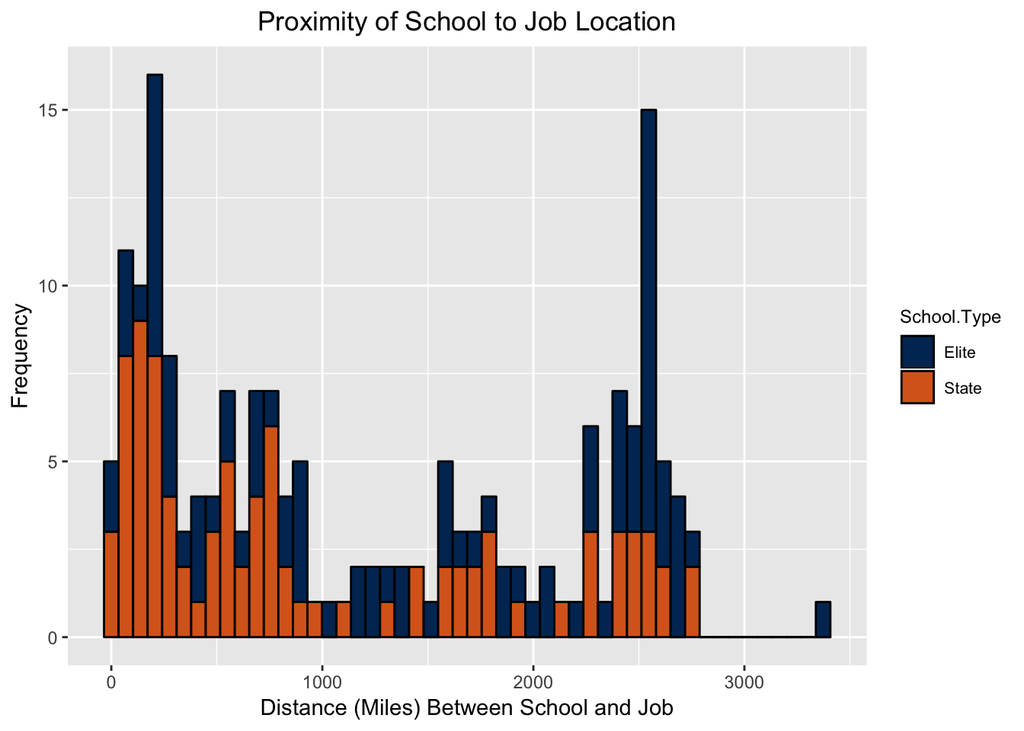

###### Salary

The salary measure reflects, in dollars, the midpoint value of the annual salary range advertised for the job position. Data is not included for positions that offered hourly rates, most commonly seen in the teacher block, as we did not have a means by which to annualize the rate for an apples-to-apples comparison of salary data. Salary was selected as a covariate of interest because we believed that employers offering more competitive compensation are likely to receive a greater number of applicants, thus increasing the competition for the job and affecting our likelihood of a response. This histogram shows the distribution of salary for our job applications, with the greatest number of positions falling in the $60-100k range.

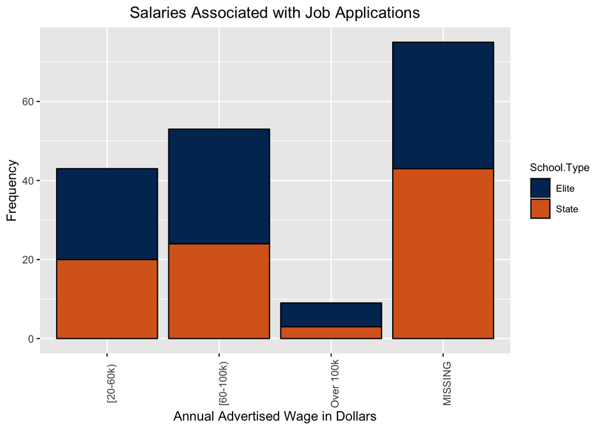

Note: 75 of the positions did not supply salary information.

## Average Treatment Effect

We first examine our results by using regression to measure the overall, unblocked average treatment effect of an applicant graduating from an elite university.

Without the inclusion of covariates, no statistically significant treatment effect is observed. Response rates for elite schools show a difference of -0.02 with a standard error of 0.05. Given the associated p-value of 0.66, the unblocked treatment effect does not allow us to reject the null hypothesis that even positive response rates will be regardless of undergraduate institution.

Next, we test to see if any of our covariates are statistically significant. Controlling for covariates, response rates for elite schools increase to show a difference of 0.01 with a standard error of 0.05. However, once again, given an associated p-value of 0.88, we are still unable to reject the null hypothesis.

We execute an F-test to formally assess whether inclusion of the covariates provides a statistically significant different result for treatment effects. With a p-value of 0.67, we are not able to conclude that the covariates influence the treatment effect in a statistically significant way.

#### Power Analysis

During our pilot the response rate was around 10%. We decided that the study does not want to miss a difference that is bigger that 15% between the elite and non-elite schools. Using that the power of the study was 0.84 which is adequate for our purposes.

#### Blocked

Next, we regress our outcome measures against the interaction of treatment and block assignment to understand the average treatment effect for each of job sectors. We are able to use an unweighted regression to perform this analysis because each block represents an equal share of the total sample size and the proportion of subjects assigned to treatment in each block is equal.

Without the inclusion of covariates, no statistically significant block-specific treatment effect is observed. We see that going to an elite school reduced the positive rate by -0.13. The Finance-specific treatment effect observed is 0.17 with a standard error of 0.12 and the Teacher-specific treatment effect observed is 0.17 with a standard error of 0.12. Neither finance nor teaching, when compared to Computer Science as the base case, is statistically signifant.

We did not detect any statistically significant effect between the treatment and block assignment variables. In other words, we did not observe any heterogeneous treatment effect among the three different major subgroups.

Of note, is the statistically significant effect associated with ‘Block: Finance’. This is likely due to the very low number of positive responses seen within our Finance job applications. Of 60 positions applied to, only three positive responses were received. Given the p-value associated with the result (0.02), any follow-on study to this experiment would want to re-evaluate the resume used for the profession. We might hypothesize that the finance profession is more competitive than our other job types and thus recommend strengthening the work experience specified on the resume.

Executing an F-test to formally assess whether inclusion of the covariates provides a statistically significant different result for treatment effects returns negative results. With a p-value of 0.56, we are not able to conclude that the covariates influence the treatment effect in a statistically significant way.

### Conclusion

Despite the social status associated with the Ivy League and other elite institutions, the experiment fails to find any significant causal effect linking graduation from such a prestigious school to employer interest on the online job search platform, glassdoor.com. This result held for both the overall average treatment effect and the blocked average treatment effect. One is left to hypothesize that the advantages attending an elite institution might afford its graduates originate more from the networking opportunities and university-hosted job fairs (with employers expressly interested in recruiting there), rather than when cold call applying using online platforms.

#### Next Steps

There are ways in which this experiment could be replicated and improved upon. In particular, future research could extend the audit design which we implemented by introducing some variation in resume quality so as to determine whether the effect of a job candidate’s undergraduate institution is impacted by the candidate’s qualifications. If, for example, certain employers are less likely to hire non-elite graduates because they see them as underqualified, resumes that indicate that a candidate is highly qualified would mitigate or render negligible this view. The researchers could gain more valuable insights around the undergraduate institution effect by relating it to the effect of the resume quality itself.

Furthermore, we used glassdoor.com, which had a variety of advantages in removing excessive variation in the way treatments were delivered. Other researchers could include efforts across two or more job platforms to reduce the potential bias introduced by the fact that these platforms may attract certain types of employers and users more broadly.

There is a large body of research about salaries and hiring rates for graduates of different schools that is already available, like [USNews](https://www.usnews.com/education/best-colleges/slideshows/10-national-universities-where-grads-make-highest-starting-salaries) and [PayScale](https://www.payscale.com/college-salary-report). A future study might take this information into account.

### References

1. https://beta.washingtonpost.com/news/speaking-of-science/wp/2018/07/11/every-supreme-court-justice-attended-harvard-or-yale-thats-a-problem-say-decision-making-experts/
2. https://www.cnbc.com/2019/04/18/it-costs-75925-to-go-to-yaleheres-how-much-students-actually-pay.html
3. https://medium.com/s/story/a-culture-of-prestige-98c8671ceade
4. https://www.theatlantic.com/education/archive/2013/11/why-isnt-harvard-training-more-teachers/281432/
5. http://www.shankerinstitute.org/blog/do-teachers-really-come-bottom-third-college-graduates
6. https://www.cnbc.com/2019/01/24/here-are-the-most-in-demand-jobs-for-2019.html
7. https://www.niche.com/colleges/search/top-public-universities/